# Exploring the Financial Contributions made by Wisconsin for 2012 Presidential Elections - by Umesh

#### Observation by plotting the distribution by contributed amount by date , party and top 10 cities

- Contribution for parties other than Democratic and Republican is very very less and negligible
- Democratic Party has highest contribution from Madison during both P2012 and G2012
- Republican Party has highest contribution from Milwaukee during both P2012 and G2012
- Democratic Party had got more contributions from Milwaukee than Republicans
- Difference between the contribution from Madison and Milwaukee with rest of the top 10 cities is very high
- Both Democratic and Republicans have got similar amount of contributions from top 10 cities for both general and primary elections.
- Replublican Party had more contributions from other top 10 cities than Democrats

#### Density Plot of contributions by party and elections type

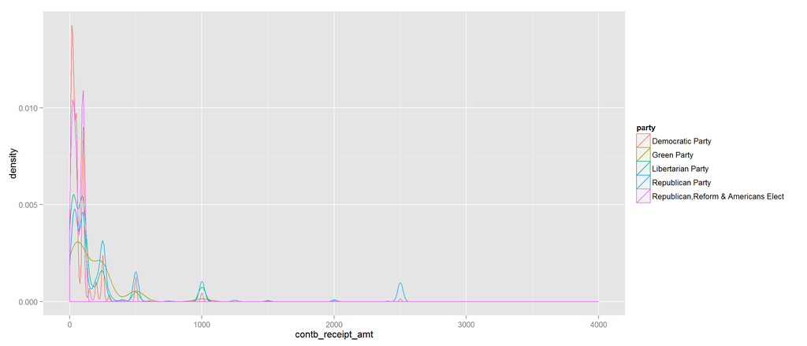

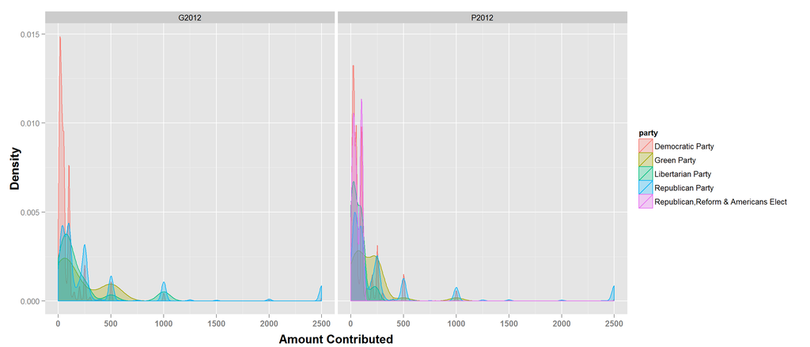

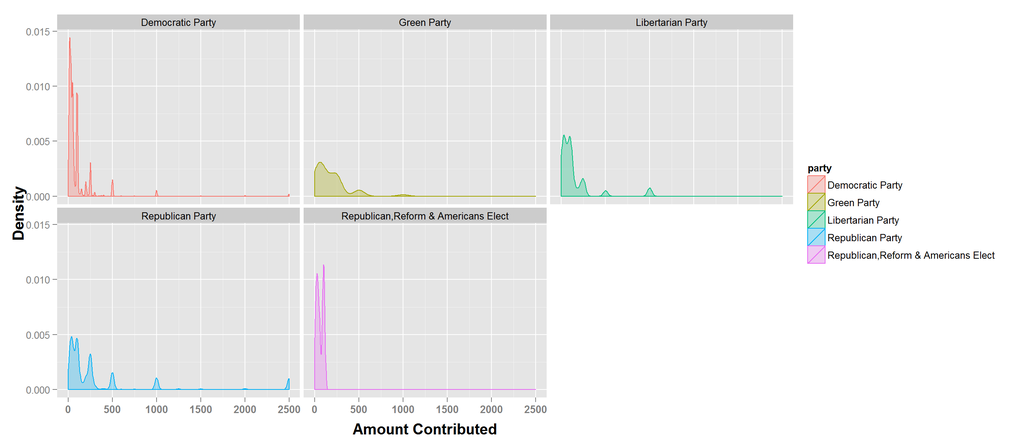

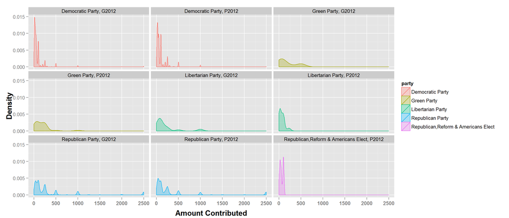

#### Observations by density plotting amount contributed by party and election type

- Density plot proves again what we had seen in initial analysis where Democratic party had huge number of contributions which are less than $100
- Republican party had more variability in the individual contributions
- Not much contributions coming for other parties
- Republicans had large number of higher contributions
- Democrats had large number of smaller contributions

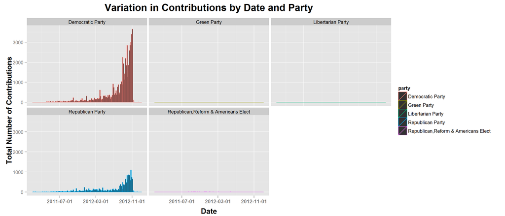

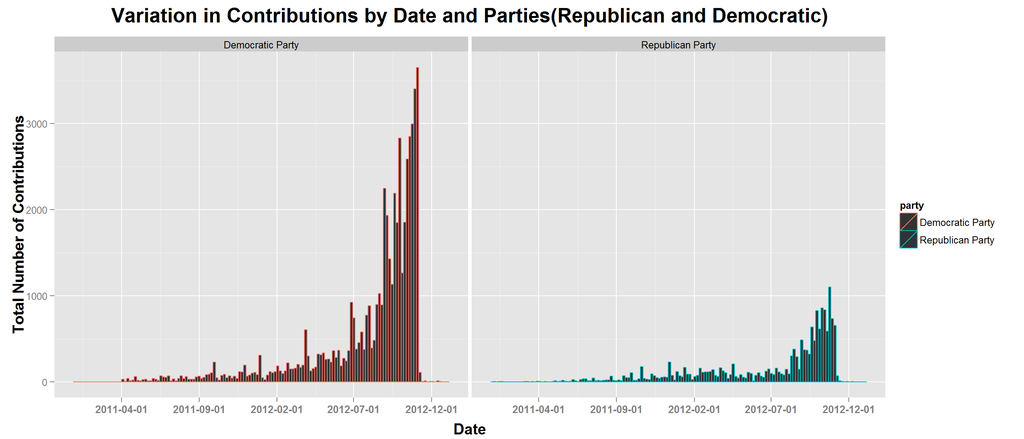

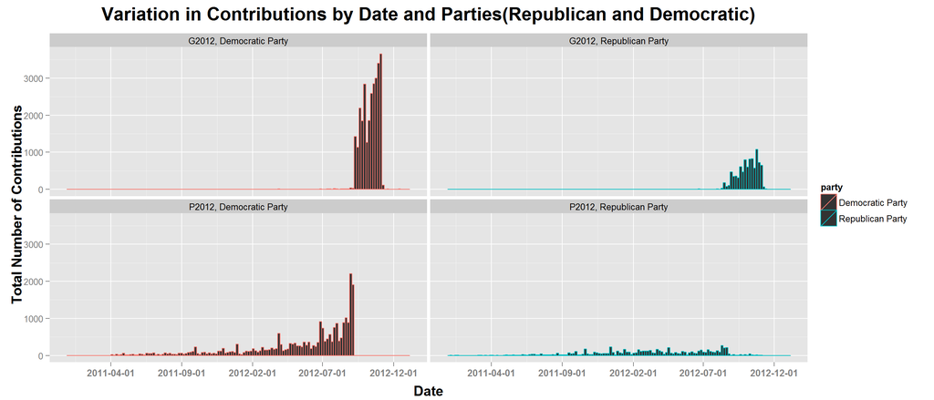

#### Observations:

- Democrats had huge number of contributions compared to Republicans
- There was huge spike in the number of contributions for the Democrats during G2012 compared to P2012
- Number of contributions for the republicans is not as high as for the democrats but still they had more amount of contributions

# Multivariate Analysis

### Talk about some of the relationships you observed in this part of the investigation. Were there features that strengthened each other in terms of looking at your feature(s) of interest?

- Contribution for parties other than Democratic and Republican is very very less and neglible.
- Democratic Party has highest contribution from Madison.
- Republican Party has highest contribution from Milwaukee
- Republicans had large number of higher contributions
- Democrats had large number of smaller contributions
- Democrats are popular among the poor and middle class.
- Republicans are popular among the higher and rich class.

# Final Plots and Summary

### Plot One

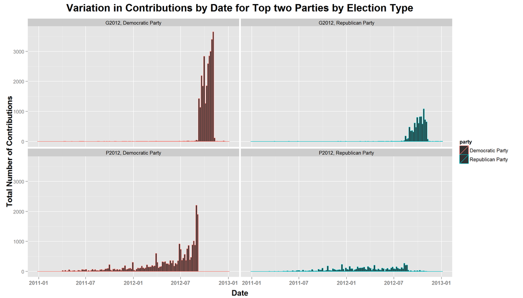

### Description One

- Democrats had huge number of contributions compared to Republicans
- There was huge spike in the number of contributions for the Democrats during G2012 compared to P2012
- Number of contributions for the republicans is not as high as for the democrats but still they had more amount of contributions

### Plot Two

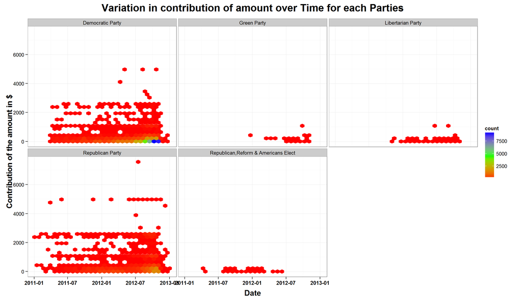

### Description Two

- Democratic party which won the elections looks to be having lesser variation in the contribution compared to the closest rival party which is Republican Party but what seems to have gone in the favour of Democratic party is those large number of small contributions

### Plot Three

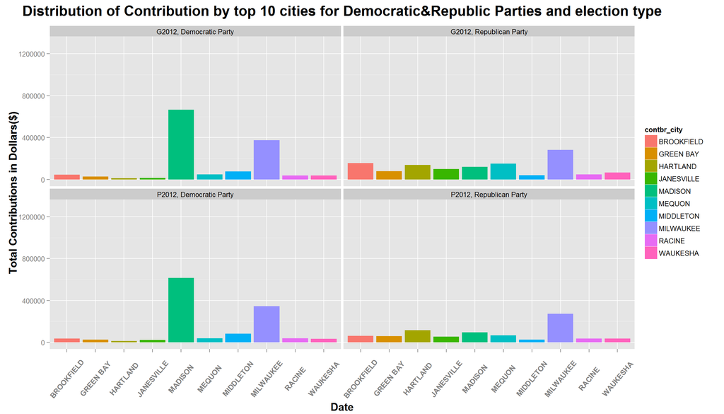

### Description Three

- Democratic Party has highest contribution from Madison
- Republican Party has highest contribution from Milwaukee
- Democratic Party had got more contributions from Milwaukee than Republicans
- Difference between the contribution from Madison and Milwaukee with rest of the top 10 cities is very high
- Both Democratic and Republicans have got similar amount of contributions from top 10 cities for both general and primary elections.
- Replublican Party had more contributions from other top 10 cities than Democrats

# Reflection

The dataset contains information about the contributions made by the people to the political parties during 2012 US Presidential Elections. I started exploring the dataset initially to get the idea about the variables and the observations.

Based on the initial look into the dataset I found that there was no information on the party to which the candidate belonged to and also the gender of the candidate. I collected the information on the party of the candidate and gender by googling and looking into some website.

Once I collected the information I updated the dataset to include two more additional variables which gives the information on the candidate gender and the party to which the candidate belongs to. I also made some modifications like cleaned the zip code variable of the contributor to five digit and also changed the type of the date field from factor to Date

Along with that I also observed that all contributions were in negative amount with election type being 2008 and also some contributions being negative for the 2012 election type. These were the refunds by the parties and candidates for the contributions made during the 2008 elections. Also the ones in negative with election type G2012/P2012 were for reattribution/redesignation in 2012. Removed the observations with negative amounts. This was a bit challenging to understand, as there is no clear understanding how these negative value observations relate to other contributions in the dataset.

Once the dataset was cleaned and ready to explore, I started plotting and checking the summaries based on the variables of interest. Along the way found how the number of contributions vary with candidates, political parties, contributors occupations,contributors cities and time.

Most interesting part was how the two important candidates and political parties faired against each other in terms of number of contributions and total amount contributed. It was very surprising to know how the winner had very less difference with the closest rival in the amount contributed. Also it was interesting to know how different cities varied their contribution based on the parties and candidates.

One more very interesting observation was even though the winner Obama had huge difference or variation in the number of contributions compared to Romney, the difference in the total amount was very small. When looked in deeper how this could happen I found that Obama had huge number of small contributions compared to Romney or Republicans who had large share of big contributions. This gives us some insight into the kind of people backing these two political parties. Democrats look to be more popular among the poor and middle class section whereas Republicans have backing of the well to do people.

Also based on the top 10 cities contributions it was very interesting to know how the people from different cities support and contribute the political parties.

I feel this kind of dataset gives the political parties huge advantage to::

- Understand their voter base and also the people who dont vote them or support them.
- Plan their political campaigns.
- Plan their government spendings
- Learn from their mistakes
- And lot more.

It would be more interesting to add more details about the contributors like :

- Giving them a unique identity or using SSN for tracking the contributions.
- Making it mandatory to share the complete details about themselves when they make the contributions.
- Their financial background and the source of money contributed
- Educational background of the people.
- Party to which they had contributed in the previous elections
- Reason for contributing. Is it party or candidate or anything else?

These details should give us more insight into the inner thoughts of the people who contribute to the elections for the parties and candidates. Also it is important for the government authorities to make sure the source of the money used in the elections is not illegal.

Overall the dataset was very interesting to get insight into the contributions made by the people of Wisconsin for the 2012 US Presidential Elections. Analyzing such dataset for entire country would be even very interesting.